# Risk Factor Analysis

## Outcome Variable

**Outcome Variable:** stunted

## Predictor Variables

**Intervention Variable:** cleanck

**Adjustment Set:**

- arm
- sex
- W_mage
- meducyrs
- feducyrs
- hhwealth_quart
- W_nrooms
- W_nhh
- W_nchldlt5
- W_parity
- impfloor
- delta_meducyrs
- delta_feducyrs
- delta_hhwealth_quart
- delta_W_nrooms
- delta_W_nhh
- delta_W_nchldlt5
- delta_W_parity
- delta_impfloor

## Stratifying Variables

The analysis was stratified on these variable(s):

- agecat
- studyid
- country

## Data Summary

| agecat | studyid | country | cleanck | stunted | n_cell | n |
| --- | --- | --- | --- | --- | --- | --- |
| Birth | ki0047075b-MAL-ED | PERU | 0 | 0 | 1 | 2 |
| Birth | ki0047075b-MAL-ED | PERU | 0 | 1 | 0 | 2 |
| Birth | ki0047075b-MAL-ED | PERU | 1 | 0 | 1 | 2 |
| Birth | ki0047075b-MAL-ED | PERU | 1 | 1 | 0 | 2 |
| Birth | ki0047075b-MAL-ED | SOUTH AFRICA | 0 | 0 | 1 | 2 |
| Birth | ki0047075b-MAL-ED | SOUTH AFRICA | 0 | 1 | 0 | 2 |
| Birth | ki0047075b-MAL-ED | SOUTH AFRICA | 1 | 0 | 0 | 2 |
| Birth | ki0047075b-MAL-ED | SOUTH AFRICA | 1 | 1 | 1 | 2 |
| Birth | ki1000108-CMC-V-BCS-2002 | INDIA | 0 | 0 | 40 | 90 |
| Birth | ki1000108-CMC-V-BCS-2002 | INDIA | 0 | 1 | 12 | 90 |
| Birth | ki1000108-CMC-V-BCS-2002 | INDIA | 1 | 0 | 34 | 90 |
| Birth | ki1000108-CMC-V-BCS-2002 | INDIA | 1 | 1 | 4 | 90 |
| Birth | ki1000108-IRC | INDIA | 0 | 0 | 138 | 378 |
| Birth | ki1000108-IRC | INDIA | 0 | 1 | 22 | 378 |
| Birth | ki1000108-IRC | INDIA | 1 | 0 | 197 | 378 |
| Birth | ki1000108-IRC | INDIA | 1 | 1 | 21 | 378 |
| Birth | ki1017093c-NIH-Crypto | BANGLADESH | 0 | 0 | 6 | 20 |
| Birth | ki1017093c-NIH-Crypto | BANGLADESH | 0 | 1 | 2 | 20 |
| Birth | ki1017093c-NIH-Crypto | BANGLADESH | 1 | 0 | 11 | 20 |
| Birth | ki1017093c-NIH-Crypto | BANGLADESH | 1 | 1 | 1 | 20 |
| 6 months | ki0047075b-MAL-ED | SOUTH AFRICA | 0 | 0 | 0 | 1 |
| 6 months | ki0047075b-MAL-ED | SOUTH AFRICA | 0 | 1 | 0 | 1 |
| 6 months | ki0047075b-MAL-ED | SOUTH AFRICA | 1 | 0 | 1 | 1 |
| 6 months | ki0047075b-MAL-ED | SOUTH AFRICA | 1 | 1 | 0 | 1 |
| 6 months | ki1000108-CMC-V-BCS-2002 | INDIA | 0 | 0 | 135 | 369 |
| 6 months | ki1000108-CMC-V-BCS-2002 | INDIA | 0 | 1 | 71 | 369 |
| 6 months | ki1000108-CMC-V-BCS-2002 | INDIA | 1 | 0 | 123 | 369 |
| 6 months | ki1000108-CMC-V-BCS-2002 | INDIA | 1 | 1 | 40 | 369 |
| 6 months | ki1000108-IRC | INDIA | 0 | 0 | 119 | 398 |
| 6 months | ki1000108-IRC | INDIA | 0 | 1 | 49 | 398 |
| 6 months | ki1000108-IRC | INDIA | 1 | 0 | 181 | 398 |
| 6 months | ki1000108-IRC | INDIA | 1 | 1 | 49 | 398 |
| 6 months | ki1017093b-PROVIDE | BANGLADESH | 0 | 0 | 76 | 583 |
| 6 months | ki1017093b-PROVIDE | BANGLADESH | 0 | 1 | 25 | 583 |
| 6 months | ki1017093b-PROVIDE | BANGLADESH | 1 | 0 | 413 | 583 |
| 6 months | ki1017093b-PROVIDE | BANGLADESH | 1 | 1 | 69 | 583 |
| 6 months | ki1017093c-NIH-Crypto | BANGLADESH | 0 | 0 | 179 | 545 |
| 6 months | ki1017093c-NIH-Crypto | BANGLADESH | 0 | 1 | 37 | 545 |
| 6 months | ki1017093c-NIH-Crypto | BANGLADESH | 1 | 0 | 264 | 545 |
| 6 months | ki1017093c-NIH-Crypto | BANGLADESH | 1 | 1 | 65 | 545 |
| 6 months | ki1113344-GMS-Nepal | NEPAL | 0 | 0 | 778 | 1008 |
| 6 months | ki1113344-GMS-Nepal | NEPAL | 0 | 1 | 214 | 1008 |
| 6 months | ki1113344-GMS-Nepal | NEPAL | 1 | 0 | 16 | 1008 |
| 6 months | ki1113344-GMS-Nepal | NEPAL | 1 | 1 | 0 | 1008 |
| 24 months | ki0047075b-MAL-ED | SOUTH AFRICA | 0 | 0 | 0 | 1 |
| 24 months | ki0047075b-MAL-ED | SOUTH AFRICA | 0 | 1 | 0 | 1 |
| 24 months | ki0047075b-MAL-ED | SOUTH AFRICA | 1 | 0 | 1 | 1 |
| 24 months | ki0047075b-MAL-ED | SOUTH AFRICA | 1 | 1 | 0 | 1 |
| 24 months | ki1000108-CMC-V-BCS-2002 | INDIA | 0 | 0 | 39 | 372 |
| 24 months | ki1000108-CMC-V-BCS-2002 | INDIA | 0 | 1 | 170 | 372 |
| 24 months | ki1000108-CMC-V-BCS-2002 | INDIA | 1 | 0 | 67 | 372 |
| 24 months | ki1000108-CMC-V-BCS-2002 | INDIA | 1 | 1 | 96 | 372 |
| 24 months | ki1000108-IRC | INDIA | 0 | 0 | 89 | 400 |
| 24 months | ki1000108-IRC | INDIA | 0 | 1 | 80 | 400 |
| 24 months | ki1000108-IRC | INDIA | 1 | 0 | 144 | 400 |
| 24 months | ki1000108-IRC | INDIA | 1 | 1 | 87 | 400 |
| 24 months | ki1017093b-PROVIDE | BANGLADESH | 0 | 0 | 49 | 577 |
| 24 months | ki1017093b-PROVIDE | BANGLADESH | 0 | 1 | 49 | 577 |
| 24 months | ki1017093b-PROVIDE | BANGLADESH | 1 | 0 | 338 | 577 |
| 24 months | ki1017093b-PROVIDE | BANGLADESH | 1 | 1 | 141 | 577 |
| 24 months | ki1017093c-NIH-Crypto | BANGLADESH | 0 | 0 | 167 | 410 |
| 24 months | ki1017093c-NIH-Crypto | BANGLADESH | 0 | 1 | 44 | 410 |
| 24 months | ki1017093c-NIH-Crypto | BANGLADESH | 1 | 0 | 156 | 410 |
| 24 months | ki1017093c-NIH-Crypto | BANGLADESH | 1 | 1 | 43 | 410 |
| 24 months | ki1113344-GMS-Nepal | NEPAL | 0 | 0 | 474 | 892 |
| 24 months | ki1113344-GMS-Nepal | NEPAL | 0 | 1 | 404 | 892 |
| 24 months | ki1113344-GMS-Nepal | NEPAL | 1 | 0 | 14 | 892 |
| 24 months | ki1113344-GMS-Nepal | NEPAL | 1 | 1 | 0 | 892 |

The following strata were considered:

- agecat: 24 months, studyid: ki0047075b-MAL-ED, country: SOUTH AFRICA
- agecat: 24 months, studyid: ki1000108-CMC-V-BCS-2002, country: INDIA
- agecat: 24 months, studyid: ki1000108-IRC, country: INDIA
- agecat: 24 months, studyid: ki1017093b-PROVIDE, country: BANGLADESH
- agecat: 24 months, studyid: ki1017093c-NIH-Crypto, country: BANGLADESH
- agecat: 24 months, studyid: ki1113344-GMS-Nepal, country: NEPAL
- agecat: 6 months, studyid: ki0047075b-MAL-ED, country: SOUTH AFRICA
- agecat: 6 months, studyid: ki1000108-CMC-V-BCS-2002, country: INDIA
- agecat: 6 months, studyid: ki1000108-IRC, country: INDIA
- agecat: 6 months, studyid: ki1017093b-PROVIDE, country: BANGLADESH
- agecat: 6 months, studyid: ki1017093c-NIH-Crypto, country: BANGLADESH
- agecat: 6 months, studyid: ki1113344-GMS-Nepal, country: NEPAL
- agecat: Birth, studyid: ki0047075b-MAL-ED, country: PERU
- agecat: Birth, studyid: ki0047075b-MAL-ED, country: SOUTH AFRICA
- agecat: Birth, studyid: ki1000108-CMC-V-BCS-2002, country: INDIA
- agecat: Birth, studyid: ki1000108-IRC, country: INDIA
- agecat: Birth, studyid: ki1017093c-NIH-Crypto, country: BANGLADESH

### Dropped Strata

Some strata were dropped due to rare outcomes:

- agecat: Birth, studyid: ki0047075b-MAL-ED, country: PERU
- agecat: Birth, studyid: ki0047075b-MAL-ED, country: SOUTH AFRICA
- agecat: Birth, studyid: ki1000108-CMC-V-BCS-2002, country: INDIA
- agecat: Birth, studyid: ki1017093c-NIH-Crypto, country: BANGLADESH
- agecat: 6 months, studyid: ki0047075b-MAL-ED, country: SOUTH AFRICA
- agecat: 6 months, studyid: ki1113344-GMS-Nepal, country: NEPAL
- agecat: 24 months, studyid: ki0047075b-MAL-ED, country: SOUTH AFRICA
- agecat: 24 months, studyid: ki1113344-GMS-Nepal, country: NEPAL

## Methods Detail

We’re interested in the causal parameters $E[Y_a]$ for all values of $a \in \mathcal{A}$. These parameters represent the mean outcome if, possibly contrary to fact, we intervened to set all units to have $A=a$. Under the randomization and positivity assumptions, these are identified by the statistical parameters $\psi_a=E_W[E_{Y|A,W}(Y|A=a,W)]$. In addition, we’re interested in the mean of $Y$, $E[Y]$ under no intervention (the observed mean). We will estimate these parameters by using SuperLearner to fit the relevant likelihood factors – $E_{Y|A,W}(Y|A=a,W)$ and $p(A=a|W)$, and then updating our likelihood fit using a joint TMLE.

For unadjusted analyses ($W=\{\}$), initial likelihoods were estimated using Lrnr_glm to estimate the simple $E(Y|A)$ and Lrnr_mean to estimate $p(A)$. For adjusted analyses, a small library containing Lrnr_glmnet, Lrnr_xgboost, and Lrnr_mean was used.

Having estimated these parameters, we will then use the delta method to estimate relative risks and attributable risks relative to a prespecified baseline level of $A$.

# Results Detail

## Results Plots

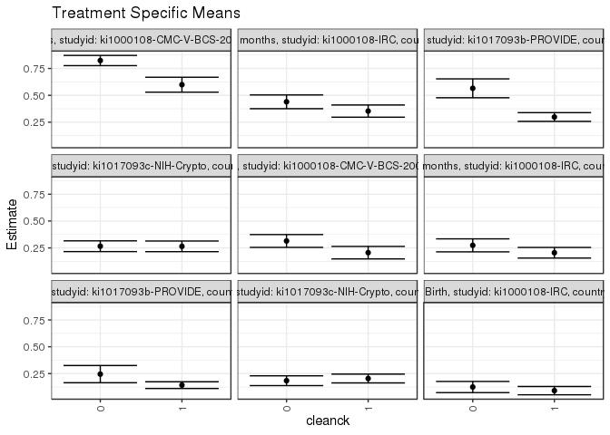

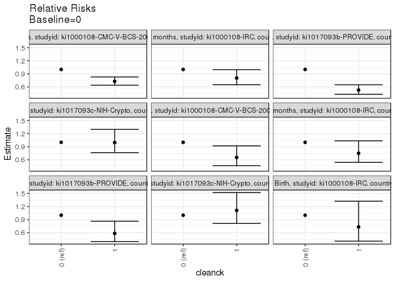

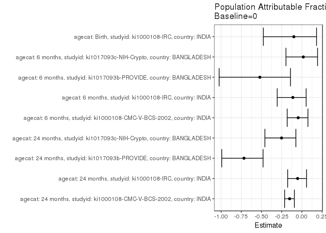

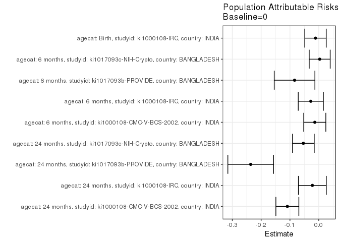

## Results Table

### Parameter: TSM

| agecat | studyid | country | intervention_level | baseline_level | estimate | ci_lower | ci_upper |
| --- | --- | --- | --- | --- | --- | --- | --- |
| Birth | ki1000108-IRC | INDIA | 0 | NA | 0.1251254 | 0.0729871 | 0.1772636 |
| Birth | ki1000108-IRC | INDIA | 1 | NA | 0.0915964 | 0.0530307 | 0.1301621 |
| 6 months | ki1000108-CMC-V-BCS-2002 | INDIA | 0 | NA | 0.3146532 | 0.2549624 | 0.3743440 |
| 6 months | ki1000108-CMC-V-BCS-2002 | INDIA | 1 | NA | 0.2056046 | 0.1474577 | 0.2637514 |
| 6 months | ki1000108-IRC | INDIA | 0 | NA | 0.2738876 | 0.2133860 | 0.3343892 |
| 6 months | ki1000108-IRC | INDIA | 1 | NA | 0.2049251 | 0.1554232 | 0.2544270 |
| 6 months | ki1017093b-PROVIDE | BANGLADESH | 0 | NA | 0.2452160 | 0.1650068 | 0.3254251 |
| 6 months | ki1017093b-PROVIDE | BANGLADESH | 1 | NA | 0.1429252 | 0.1117044 | 0.1741459 |
| 6 months | ki1017093c-NIH-Crypto | BANGLADESH | 0 | NA | 0.1839387 | 0.1384662 | 0.2294113 |
| 6 months | ki1017093c-NIH-Crypto | BANGLADESH | 1 | NA | 0.2044662 | 0.1634478 | 0.2454846 |
| 24 months | ki1000108-CMC-V-BCS-2002 | INDIA | 0 | NA | 0.8240138 | 0.7763694 | 0.8716582 |
| 24 months | ki1000108-CMC-V-BCS-2002 | INDIA | 1 | NA | 0.5990400 | 0.5296167 | 0.6684633 |
| 24 months | ki1000108-IRC | INDIA | 0 | NA | 0.4397284 | 0.3757572 | 0.5036995 |
| 24 months | ki1000108-IRC | INDIA | 1 | NA | 0.3532247 | 0.2965009 | 0.4099484 |
| 24 months | ki1017093b-PROVIDE | BANGLADESH | 0 | NA | 0.5654685 | 0.4774876 | 0.6534494 |
| 24 months | ki1017093b-PROVIDE | BANGLADESH | 1 | NA | 0.2981298 | 0.2575773 | 0.3386823 |
| 24 months | ki1017093c-NIH-Crypto | BANGLADESH | 0 | NA | 0.2656593 | 0.2156762 | 0.3156424 |
| 24 months | ki1017093c-NIH-Crypto | BANGLADESH | 1 | NA | 0.2643645 | 0.2149001 | 0.3138288 |

### Parameter: E(Y)

| agecat | studyid | country | intervention_level | baseline_level | estimate | ci_lower | ci_upper |
| --- | --- | --- | --- | --- | --- | --- | --- |
| Birth | ki1000108-IRC | INDIA | NA | NA | 0.1137566 | 0.0817056 | 0.1458077 |
| 6 months | ki1000108-CMC-V-BCS-2002 | INDIA | NA | NA | 0.3008130 | 0.2539566 | 0.3476694 |
| 6 months | ki1000108-IRC | INDIA | NA | NA | 0.2462312 | 0.2038529 | 0.2886094 |
| 6 months | ki1017093b-PROVIDE | BANGLADESH | NA | NA | 0.1612350 | 0.1313580 | 0.1911120 |
| 6 months | ki1017093c-NIH-Crypto | BANGLADESH | NA | NA | 0.1871560 | 0.1543801 | 0.2199318 |
| 24 months | ki1000108-CMC-V-BCS-2002 | INDIA | NA | NA | 0.7150538 | 0.6691221 | 0.7609854 |
| 24 months | ki1000108-IRC | INDIA | NA | NA | 0.4175000 | 0.3691120 | 0.4658880 |
| 24 months | ki1017093b-PROVIDE | BANGLADESH | NA | NA | 0.3292894 | 0.2909105 | 0.3676684 |
| 24 months | ki1017093c-NIH-Crypto | BANGLADESH | NA | NA | 0.2121951 | 0.1725707 | 0.2518196 |

### Parameter: RR

| agecat | studyid | country | intervention_level | baseline_level | estimate | ci_lower | ci_upper |
| --- | --- | --- | --- | --- | --- | --- | --- |
| Birth | ki1000108-IRC | INDIA | 0 | 0 | 1.0000000 | 1.0000000 | 1.0000000 |
| Birth | ki1000108-IRC | INDIA | 1 | 0 | 0.7320371 | 0.4053272 | 1.3220883 |
| 6 months | ki1000108-CMC-V-BCS-2002 | INDIA | 0 | 0 | 1.0000000 | 1.0000000 | 1.0000000 |
| 6 months | ki1000108-CMC-V-BCS-2002 | INDIA | 1 | 0 | 0.6534323 | 0.4648675 | 0.9184849 |
| 6 months | ki1000108-IRC | INDIA | 0 | 0 | 1.0000000 | 1.0000000 | 1.0000000 |
| 6 months | ki1000108-IRC | INDIA | 1 | 0 | 0.7482088 | 0.5407995 | 1.0351646 |
| 6 months | ki1017093b-PROVIDE | BANGLADESH | 0 | 0 | 1.0000000 | 1.0000000 | 1.0000000 |
| 6 months | ki1017093b-PROVIDE | BANGLADESH | 1 | 0 | 0.5828542 | 0.3937331 | 0.8628157 |
| 6 months | ki1017093c-NIH-Crypto | BANGLADESH | 0 | 0 | 1.0000000 | 1.0000000 | 1.0000000 |
| 6 months | ki1017093c-NIH-Crypto | BANGLADESH | 1 | 0 | 1.1115997 | 0.8114319 | 1.5228066 |
| 24 months | ki1000108-CMC-V-BCS-2002 | INDIA | 0 | 0 | 1.0000000 | 1.0000000 | 1.0000000 |
| 24 months | ki1000108-CMC-V-BCS-2002 | INDIA | 1 | 0 | 0.7269781 | 0.6388366 | 0.8272806 |
| 24 months | ki1000108-IRC | INDIA | 0 | 0 | 1.0000000 | 1.0000000 | 1.0000000 |
| 24 months | ki1000108-IRC | INDIA | 1 | 0 | 0.8032792 | 0.6479629 | 0.9958249 |
| 24 months | ki1017093b-PROVIDE | BANGLADESH | 0 | 0 | 1.0000000 | 1.0000000 | 1.0000000 |
| 24 months | ki1017093b-PROVIDE | BANGLADESH | 1 | 0 | 0.5272262 | 0.4292976 | 0.6474936 |
| 24 months | ki1017093c-NIH-Crypto | BANGLADESH | 0 | 0 | 1.0000000 | 1.0000000 | 1.0000000 |
| 24 months | ki1017093c-NIH-Crypto | BANGLADESH | 1 | 0 | 0.9951260 | 0.7629455 | 1.2979639 |

### Parameter: PAR

| agecat | studyid | country | intervention_level | baseline_level | estimate | ci_lower | ci_upper |
| --- | --- | --- | --- | --- | --- | --- | --- |
| Birth | ki1000108-IRC | INDIA | 0 | NA | -0.0113687 | -0.0485823 | 0.0258448 |
| 6 months | ki1000108-CMC-V-BCS-2002 | INDIA | 0 | NA | -0.0138402 | -0.0521856 | 0.0245052 |
| 6 months | ki1000108-IRC | INDIA | 0 | NA | -0.0276565 | -0.0712602 | 0.0159473 |
| 6 months | ki1017093b-PROVIDE | BANGLADESH | 0 | NA | -0.0839810 | -0.1545277 | -0.0134343 |
| 6 months | ki1017093c-NIH-Crypto | BANGLADESH | 0 | NA | 0.0032172 | -0.0331976 | 0.0396320 |
| 24 months | ki1000108-CMC-V-BCS-2002 | INDIA | 0 | NA | -0.1089601 | -0.1488059 | -0.0691142 |
| 24 months | ki1000108-IRC | INDIA | 0 | NA | -0.0222284 | -0.0705162 | 0.0260595 |
| 24 months | ki1017093b-PROVIDE | BANGLADESH | 0 | NA | -0.2361791 | -0.3154277 | -0.1569305 |
| 24 months | ki1017093c-NIH-Crypto | BANGLADESH | 0 | NA | -0.0534642 | -0.0911287 | -0.0157996 |

### Parameter: PAF

| agecat | studyid | country | intervention_level | baseline_level | estimate | ci_lower | ci_upper |
| --- | --- | --- | --- | --- | --- | --- | --- |
| Birth | ki1000108-IRC | INDIA | 0 | NA | -0.0999391 | -0.4776781 | 0.1812384 |
| 6 months | ki1000108-CMC-V-BCS-2002 | INDIA | 0 | NA | -0.0460094 | -0.1820332 | 0.0743613 |
| 6 months | ki1000108-IRC | INDIA | 0 | NA | -0.1123191 | -0.3057371 | 0.0524481 |
| 6 months | ki1017093b-PROVIDE | BANGLADESH | 0 | NA | -0.5208606 | -1.0248036 | -0.1423415 |
| 6 months | ki1017093c-NIH-Crypto | BANGLADESH | 0 | NA | 0.0171901 | -0.1974920 | 0.1933848 |
| 24 months | ki1000108-CMC-V-BCS-2002 | INDIA | 0 | NA | -0.1523802 | -0.2142011 | -0.0937069 |
| 24 months | ki1000108-IRC | INDIA | 0 | NA | -0.0532416 | -0.1765264 | 0.0571246 |
| 24 months | ki1017093b-PROVIDE | BANGLADESH | 0 | NA | -0.7172387 | -0.9920687 | -0.4803248 |
| 24 months | ki1017093c-NIH-Crypto | BANGLADESH | 0 | NA | -0.2519576 | -0.4582453 | -0.0748520 |